# NYC Airbnb Data

## Goal

The goal of this analysis is to try to find patterns in the raw data, and use them to learn something useful about apartment-hunting, and New York in general.

## Data

Dataset used for this project is [New York City Airbnb Open Data](https://www.kaggle.com/dgomonov/new-york-city-airbnb-open-data), and it contains various information about all listings in the Big Apple from 2019.

```r
suppressPackageStartupMessages(library(tidyverse))
library(ggthemes)
theme_set(theme_minimal())
suppressPackageStartupMessages(library(lubridate))
nycdata <- read.csv('../data/AB_NYC_2019.csv')
head(nycdata, 5)                                    #show first five listings
```

|  | id | name | host_id | host_name | neighbourhood_group | neighbourhood | latitude | longitude | room_type | price | minimum_nights | number_of_reviews | last_review | reviews_per_month | calculated_host_listings_count | availability_365 |
| --- | --- | --- | --- | --- | --- | --- | --- | --- | --- | --- | --- | --- | --- | --- | --- | --- |
| 1 | 2539 | Clean & quiet apt home by the park | 2787 | John | Brooklyn | Kensington | 40.64749 | -73.97237 | Private room | 149 | 1 | 9 | 2018-10-19 | 0.21 | 6 | 365 |
| 2 | 2595 | Skylit Midtown Castle | 2845 | Jennifer | Manhattan | Midtown | 40.75362 | -73.98377 | Entire home/apt | 225 | 1 | 45 | 2019-05-21 | 0.38 | 2 | 355 |
| 3 | 3647 | THE VILLAGE OF HARLEM....NEW YORK ! | 4632 | Elisabeth | Manhattan | Harlem | 40.80902 | -73.94190 | Private room | 150 | 3 | 0 |  | NA | 1 | 365 |
| 4 | 3831 | Cozy Entire Floor of Brownstone | 4869 | LisaRoxanne | Brooklyn | Clinton Hill | 40.68514 | -73.95976 | Entire home/apt | 89 | 1 | 270 | 2019-07-05 | 4.64 | 1 | 194 |
| 5 | 5022 | Entire Apt: Spacious Studio/Loft by central park | 7192 | Laura | Manhattan | East Harlem | 40.79851 | -73.94399 | Entire home/apt | 80 | 10 | 9 | 2018-11-19 | 0.10 | 1 | 0 |

## The city

To help us truly understand this data, it is important to get to know the city of New York first.

Located on the far east coast of the United States, New York is its most pupulous city with over 8 million people. It consists of five bouroughs - **Brooklyn**, **Queens**, **Manhattan**, **Bronx** and the **Staten Island**.

It also has two airports, **JFK** and **LaGuardia**, which are the sixth and the twentieth busiest airports in the US respectively, handling around 100 million passengers every year, and they are both located in Queens.

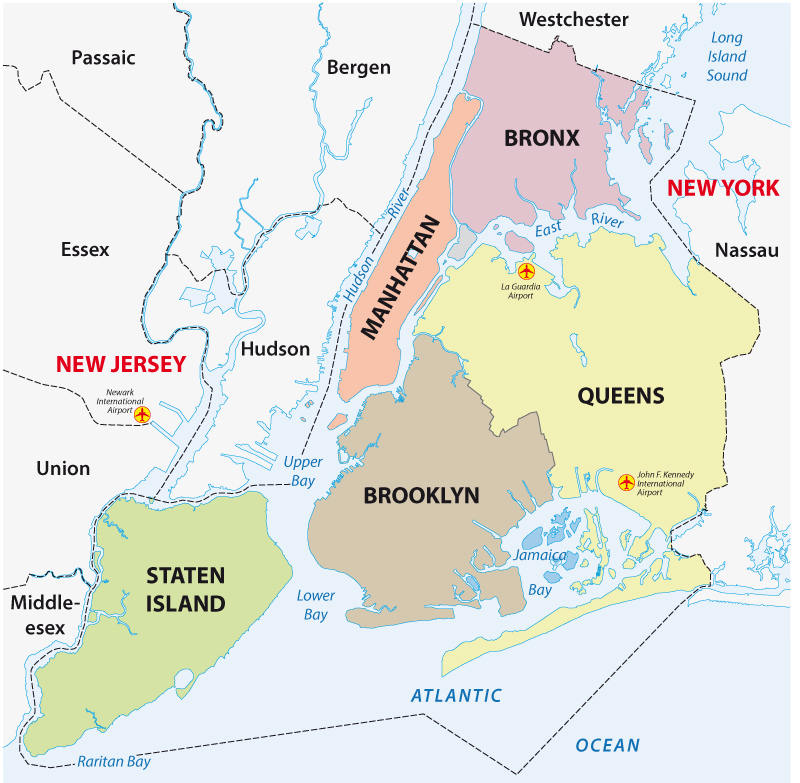

## Data Wrangling

First let’s look at all comunn types in the data:

```r
sapply(nycdata, class)
```

```
                            id                           name                        host_id
                     "integer"                       "factor"                      "integer"
                     host_name            neighbourhood_group                  neighbourhood
                      "factor"                       "factor"                       "factor"
                      latitude                      longitude                      room_type
                     "numeric"                      "numeric"                       "factor"
                         price                 minimum_nights              number_of_reviews
                     "integer"                      "integer"                      "integer"
                   last_review              reviews_per_month calculated_host_listings_count
                      "factor"                      "numeric"                      "integer"
              availability_365
                     "integer"
```

It seems that column last_review is a factor while it represents a date, so we should convert it to date.

```r
nycdata <- nycdata %>%
  mutate(last_review = ymd(last_review))
```

### Missing Values

Let’s find the names of all the columns that contain the missing values

```r
colnames(nycdata)[colSums(is.na(nycdata)) > 0]
```

```
[1] "last_review"       "reviews_per_month"
```

It would appear that missing values in these two columns appear together, so let’s confirm that hypothesis.

```r
nycdata %>%
  filter(is.na(last_review) & !is.na(reviews_per_month))
```

| id | name | host_id | host_name | neighbourhood_group | neighbourhood | latitude | longitude | room_type | price | minimum_nights | number_of_reviews | last_review | reviews_per_month | calculated_host_listings_count | availability_365 |
| --- | --- | --- | --- | --- | --- | --- | --- | --- | --- | --- | --- | --- | --- | --- | --- |

Since there are 0 rows that only have one missing value, our hypothesis has been confirmed.  
From the looks of things, the rows that contain missing values in these columns are listings that have not had a single tenant so far.  
That’s why we should set missing values of reviews_per_month to 0 to keep it consistent with othere values in this column.

```r
nycdata <- nycdata %>%
  mutate(reviews_per_month = ifelse(is.na(reviews_per_month), 0, reviews_per_month))
```

There is a somewhat weird pattern in the distribution of values in the column availability_365 which represents the number of days in a year that the listing is available for booking:

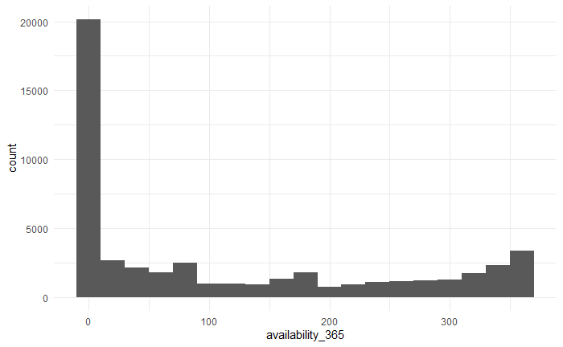

```r
ggplot(data = nycdata, mapping = aes(x = availability_365)) +
  geom_histogram(binwidth = 20)
```

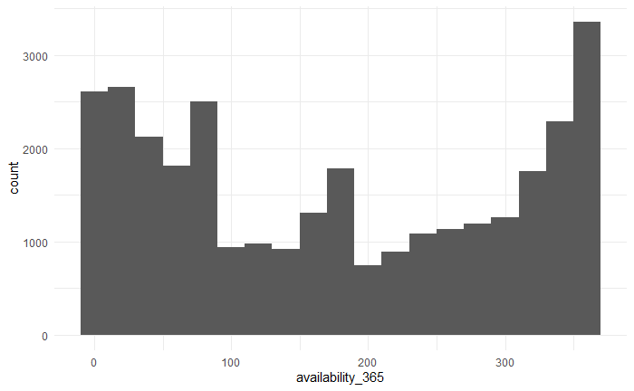

```r
nycdata <- nycdata %>%
  mutate(availability_365 = ifelse(availability_365 <= 0, NA, availability_365 ))


ggplot(data = nycdata, mapping = aes(x = availability_365)) +
  geom_histogram(binwidth = 20, na.rm = TRUE)
```

## The Locations

Location is the most important attribute when it comes to any type of real-estate, so let’s see where are these listings located in New York.

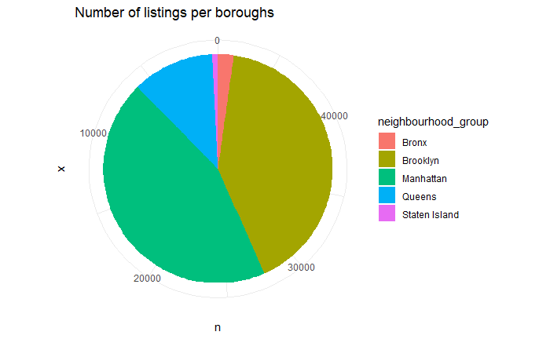

```r
nycdata %>%
  group_by(neighbourhood_group) %>%
  summarise(perc = (n()/ nrow(nycdata)*100), n = n()) %>%
  ggplot(mapping = aes(x = '', y = n, fill = neighbourhood_group)) +
  geom_bar(stat="identity") +
  coord_polar(theta = "y", start=0, direction = -1) +
  labs(title = 'Number of listings per boroughs')
```

It is very interesting that Manhattan in spite of being by far the smallest borough(only 59 km²) has the most listings, while Queens which is almost 7 times bigger and where both airports are located has significanlty less.

Let’s dive deeper, and try to see why Manhattan is so popular among the user of this app.